# Effective Data Visualisation with R **The {ggplot2} Package**

Paul Murrell The University of Auckland

# Review

- A data visualisation is made up of data symbols and labels.
- **data symbols** represent **data values**.
- Our goal is to learn how to choose an effective **mapping** from **data values** to **data symbols**.

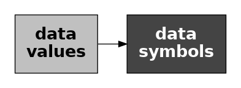

# How To Draw

- **What to draw:**  
  Many sections will focus primarily on the choice of data symbols to use in a data visualisation.
- **How to draw:**  
  In this section we will focus on writing R code to create data visualisations, using the {ggplot2} package.
- Later sections will supplement advice on what to draw with further information about {ggplot2}.

# {ggplot2}

- Geoms
- Aesthetics
- Scales
- Stats

# A Grammar of Graphics

- {ggplot2} is built on a set of basic building blocks:
  - The **data** to visualise, as a data frame.
  - A **geom** to use as a data symbol  
    *(e.g., a point or a bar)*.
  - **mappings** from data to **aesthetics**  
    *(e.g., map the number of crimes to the **height** of a bar)*.

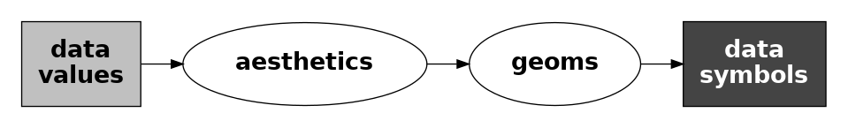

# ggplot2 Code

```r
library(ggplot2)
```

The code for a {ggplot2} data visualisation has the following format:

```
ggplot(data) +
    geom_shape(aes(mappings))
```

# ggplot2 Code

- For simple demonstrations, we will work with the total number of youth offences from 2010 to 2020, categorised by the level of crime severity.

```r
head(crimeLevelTotal)
```

```
# A tibble: 5 × 3
  level       total   prop
  <ord>       <int>  <dbl>
1 Low         24242 0.283
2 Low-Medium  21513 0.251
3 Medium      13823 0.161
4 Medium-High 18315 0.214
5 High         7793 0.0909
```

# ggplot2 Code

- In the following code:
  - the **data** is `crimeLevelTotal`.
  - the **geom** is a `col`umn (or bar).
  - `level` **maps** to the `x` position of the columns and `total` **maps** to the `y` position of (the tops of) the columns.

  ```r
  ggplot(crimeLevelTotal) +
      geom_col(aes(x=level, y=total))
  ```

# ggplot2 Code

```r
ggplot(crimeLevelTotal) +
    geom_col(aes(x=level, y=total))
```

[output not shown]

# WARNING

- Many code examples have been deliberately simplified.
- Some code examples will not exactly correspond to the details of the accompanying data visualisation.
- In some cases, warning messages have also been suppressed.

Geoms

# Geoms

- We choose a **geom** as the shape to draw for the **data symbols**.

# Geoms

- We can draw rectangles with `geom_col`.

```r
ggplot(crimeLevelTotal) +
    geom_col(aes(x=level, y=total))
```

[output not shown]

# Geoms

- We can draw points with `geom_point`.

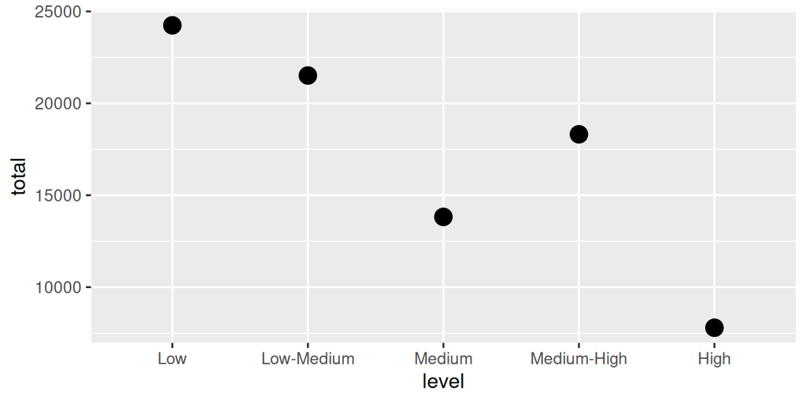

```r
ggplot(crimeLevelTotal) +
    geom_point(aes(x=level, y=total))
```

- We can draw lines with `geom_line()`.

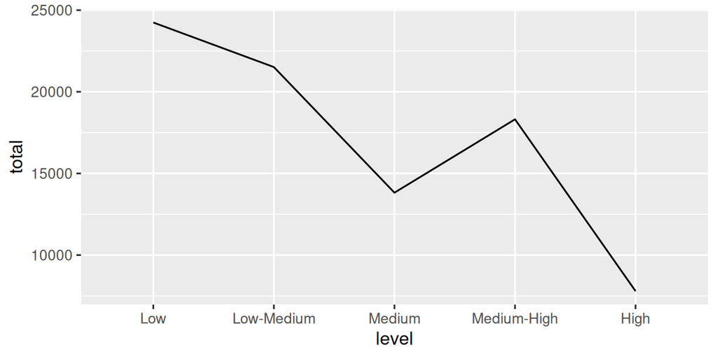

```r
ggplot(crimeLevelTotal) +
    geom_line(aes(x=level, y=total, group=1))
```

- We need `group=1` to tell {ggplot2} that all of the positions belong to the same line.

# Geoms

| Function | Shape | Function | Shape |
| --- | --- | --- | --- |
| `geom_col()` | Rectangle | `geom_line()` | Line |
| `geom_bar()` |  | `geom_path()` |  |
| `geom_tile()` |  | `geom_segment()` |  |
| `geom_rect()` |  | `geom_curve()` |  |
| `geom_point()` | Data point | `geom_text()` | Text |
| `geom_jitter()` |  | `geom_label()` |  |
| `geom_polygon()` | Polygon | `geom_raster()` | Bitmap |

Aesthetics

# Aesthetics

- An **aesthetic** is something that affects how a **geom** is drawn.
  - Where do we draw the geom?
  - What size is it?
  - What colour is it?
- An aesthetic **mapping** specifies that a data variable controls how a geom is drawn.

# Aesthetics

- The `x` and `y` aesthetics map data values to **positions**.

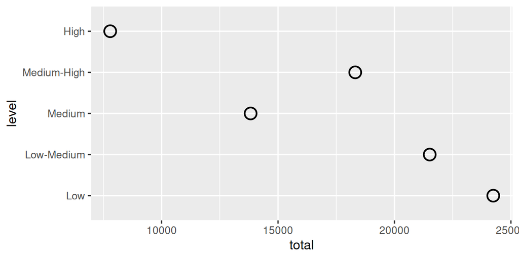

```r
ggplot(crimeLevelTotal) +
    geom_point(aes(x=total, y=level))
```

# Aesthetics

- The `size` aesthetics map data values to **size**.

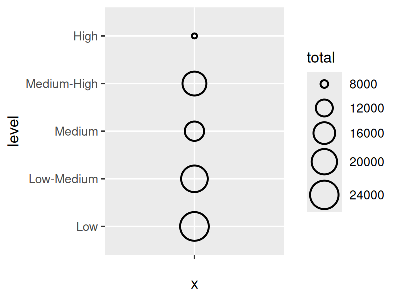

```r
ggplot(crimeLevelTotal) +
    geom_point(aes(x="", y=level, size=total))
```

# Aesthetics

- The `shape` aesthetics map data values to **shape**.

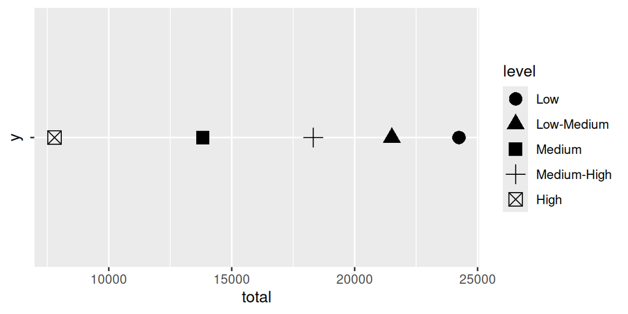

```r
ggplot(crimeLevelTotal) +
    geom_point(aes(x=total, y="", shape=level))
```

# Aesthetics

- The `colour` aesthetics map data values to **colour**.

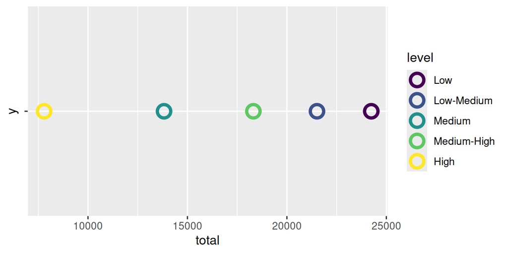

```r
ggplot(crimeLevelTotal) +
    geom_point(aes(x=total, y="", colour=level))
```

# Aesthetics

- The `fill` aesthetics map data values to **fill colour**.

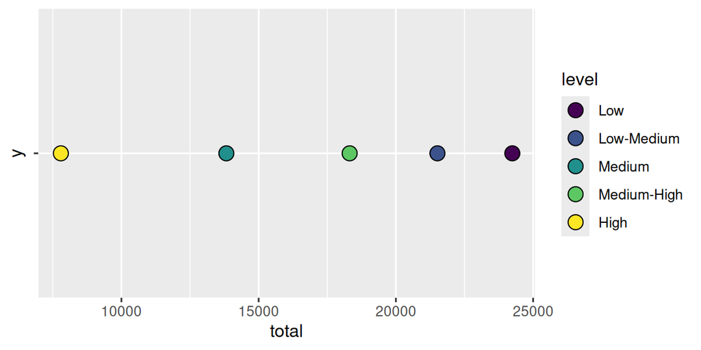

```r
ggplot(crimeLevelTotal) +
    geom_point(aes(x=total, y="", fill=level))
```

# Aesthetics

- Different geoms can have different aesthetics.
  - Only `geom_point()` has a `shape` aesthetic.
- The same aesthetic can mean different things for different geoms.

# Aesthetics

- The `x` and `y` aesthetics map data values to **positions**.
- For `geom_line()` that means x- and y-locations.

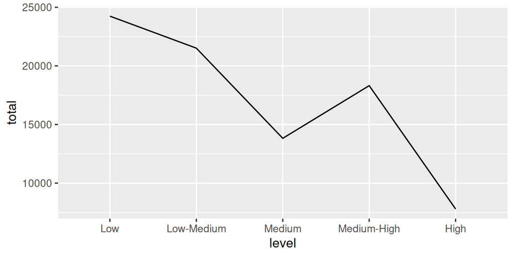

```r
ggplot(crimeLevelTotal) +
    geom_line(aes(x=level, y=total, group=1))
```

# Aesthetics

- The `x` and `y` aesthetics map data values to **positions**.
- For `geom_col()` that means the x-centre and y-top.

```r
ggplot(crimeLevelTotal) +
    geom_col(aes(x=level, y=total))
```

[output not shown]

# Aesthetics

- Aesthetics outside of `aes()` are **settings** (not mappings).

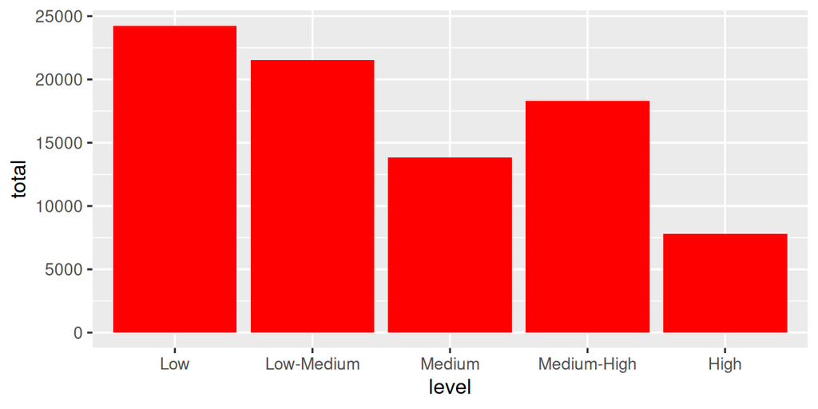

```r
ggplot(crimeLevelTotal) +
    geom_col(aes(x=level, y=total),
             fill="red")
```

# Aesthetics

- Some aesthetics are used more for settings.

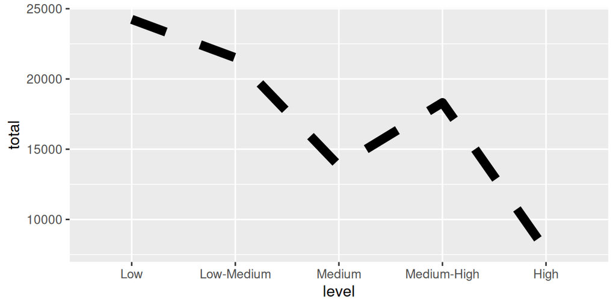

| Aesthetic | Meaning | Aesthetic | Meaning |
| --- | --- | --- | --- |
| `x` | Position (x) | `y` | Position (y) |
| `width` | Length (x) | `height` | Length (y) |
| `colour` | Border colour | `fill` | Fill colour |
| `alpha` | Level of transparency |  |  |
| `linetype` | Line style | `linewidth` | Line width |
| `shape` | Shape of points |  |  |
| `size` | Size of points and text |  |  |
| `label` | Text label |  |  |
| `family` | Font family | `fontface` | Font face |
| `hjust` | Justification (x) | `vjust` | Justification (y) |
| `lineheight` | Interline spacing |  |  |
| `group` | Group membership |  |  |

```r
ggplot(crimeLevelTotal) +
    geom_line(aes(x=level, y=total, group=1),
              linewidth=3, linetype="dashed")
```

Scales

# Scales

- **Scales** control how data values are mapped to aesthetic values.
- {ggplot2} will provide a default scale, but we can change the defaults using scale functions.

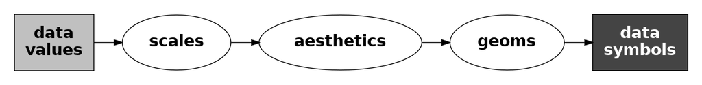

# Scales

- `scale_x_continuous()` controls the axis range and the axis labelling when quantitative data is mapped to `x`.
- `scale_x_discrete()` controls the axis range and labelling when qualitative data is mapped to `x`.
- There are also `scale_y_continuous()` and `scale_y_discrete()`.

# Scales

```r
ggplot(crimeLevelTotal) +
    geom_col(aes(x=level, y=total))
```

[output not shown]

# Scales

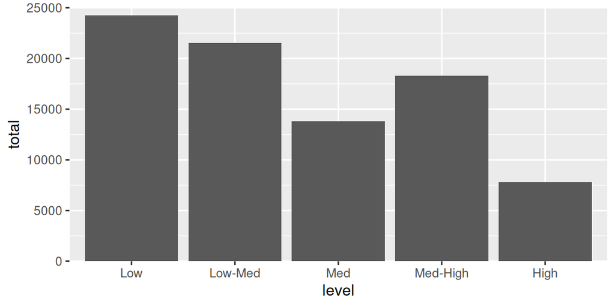

```r
ggplot(crimeLevelTotal) +
    geom_col(aes(x=level, y=total)) +
    scale_y_continuous(limits=c(0, 25000), expand=expansion(0)) +
    scale_x_discrete(labels=c("Low", "Low-Med", "Med",
                              "Med-High", "High"))
```

# Scales

- `scale_colour_continuous()` controls the colour gradient when quantitative data is mapped to `colour`.
- `scale_colour_discrete()` controls the palette of colours when qualitative data is mapped to `colour`.
- There are also `scale_fill_continuous()` and `scale_fill_discrete()`.
- We will talk more about selecting colours later on.

# Scales

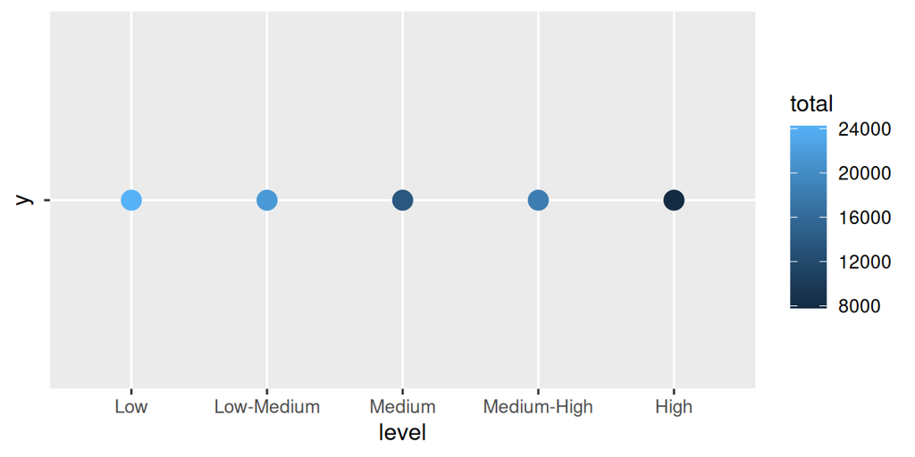

```r
ggplot(crimeLevelTotal) +
    geom_point(aes(x=level, y="", colour=total))
```

# Scales

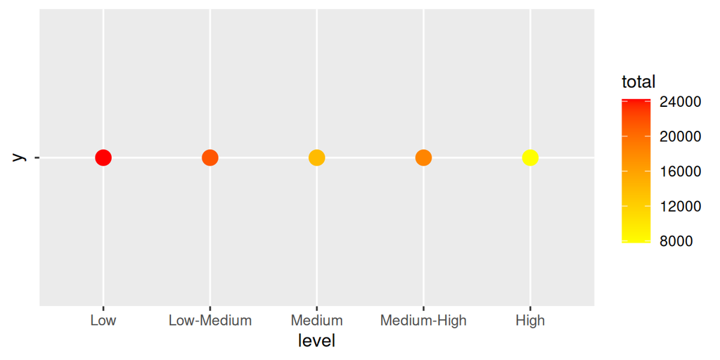

```r
ggplot(crimeLevelTotal) +
    geom_point(aes(x=level, y="", colour=total)) +
    scale_colour_continuous(low="yellow", high="red")
```

# Scales

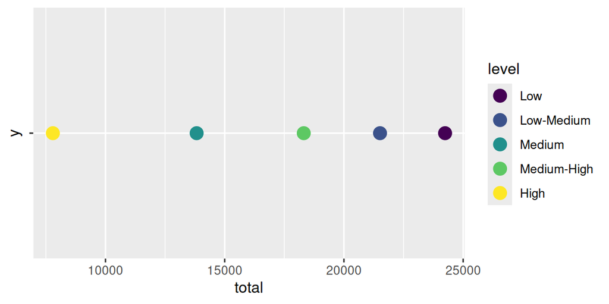

```r
ggplot(crimeLevelTotal) +
    geom_point(aes(x=total, y="", colour=level))
```

# Scales

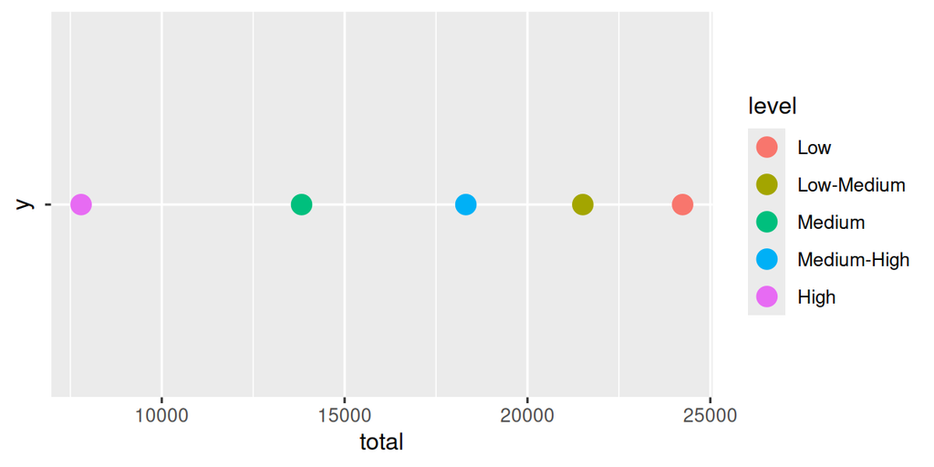

```r
ggplot(crimeLevelTotal) +
    geom_point(aes(x=total, y="", colour=level)) +
    scale_colour_discrete(type=scale_colour_hue)
```

# Scales

- `scale_size()` controls the `range` of sizes used (in millimetres).
- There are “manual” versions of scales, e.g., `scale_shape_manual()` and `scale_linetype_manual()`, that allow a set of explicit `values` to control the aesthetic mappings.

# Scales

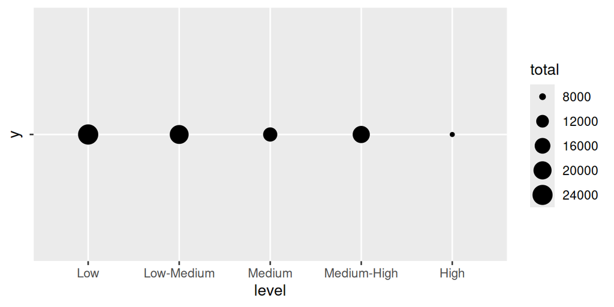

```r
ggplot(crimeLevelTotal) +
    geom_point(aes(x=level, y="", size=total))
```

# Scales

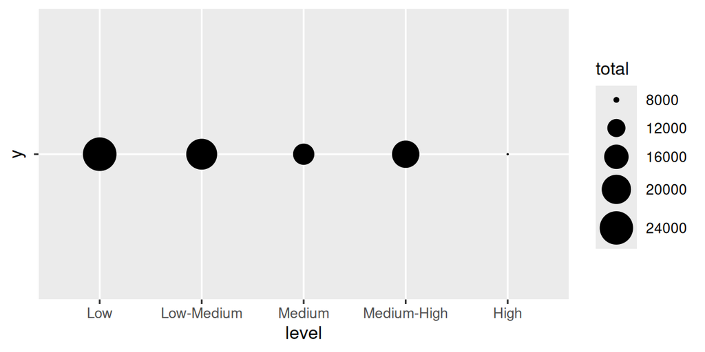

```r
ggplot(crimeLevelTotal) +
    geom_point(aes(x=level, y="", size=total)) +
    scale_size(range=c(0, 9))
```

# Scales

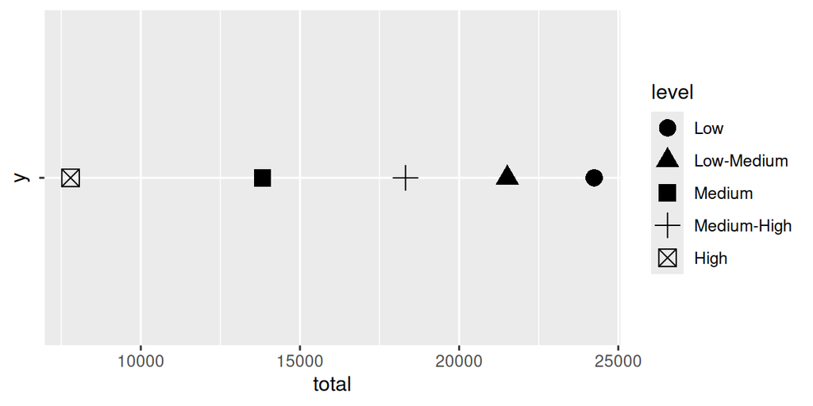

```r
ggplot(crimeLevelTotal) +
    geom_point(aes(x=total, y="", shape=level))
```

# Scales

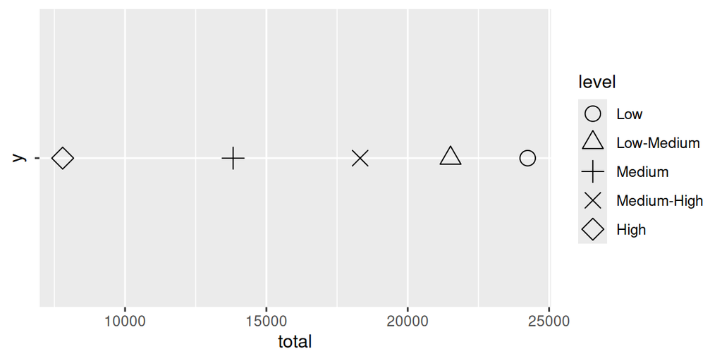

```r
ggplot(crimeLevelTotal) +
    geom_point(aes(x=total, y="", shape=level)) +
    scale_shape_manual(values=1:5)
```

Stats

# Stats

- Some **geoms** do not map the raw data.
- Some geoms apply a **stat** to transform the raw data to a set of **data statistics**.
- The data statistics are then mapped to the aesthetics of a geom.

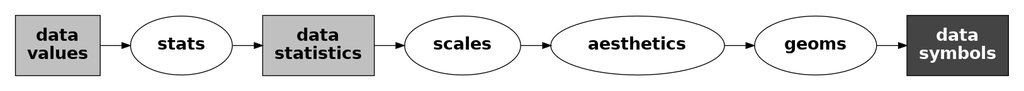

# Stats

- The `offenders` data frame contains information on individual offenders, including age group.

  ```r
  head(offenders["Age.Group"])
  ```

  ```
    Age.Group
  1     15-19
  2     15-19
  3     20-24
  4     20-24
  5     20-24
  6     20-24
  ```

# Stats

- In order to draw a bar plot of the number of offenders per age group, we need a table of counts.

  ```r
  table(offenders$Age.Group)
  ```

  ```
            0-4           5-9         10-14         15-19         20-24
              1            91          4036         11648         10920
          25-29         30-34         35-39         40-44         45-49
          11879         11468          8980          7096          5642
          50-54         55-59         60-64         65-69         70-74
           4446          2983          1853           984           616
          75-79 80yearsorover  NotSpecified
            268           252             7
  ```

- `geom_bar()` takes individual raw data and uses `stat_count()` to generate a table of counts.

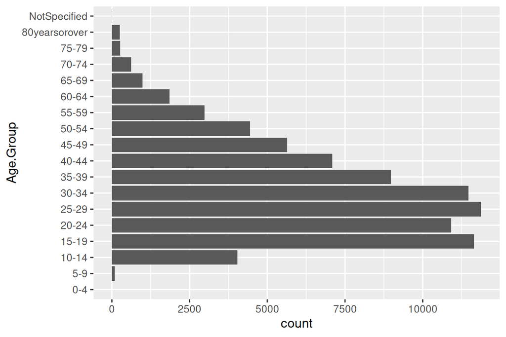

  ```r
  ggplot(offenders) +
      geom_bar(aes(y=Age.Group))
  ```

# Stats

- The unique categories map to the bar position and the counts map to the bar lengths.

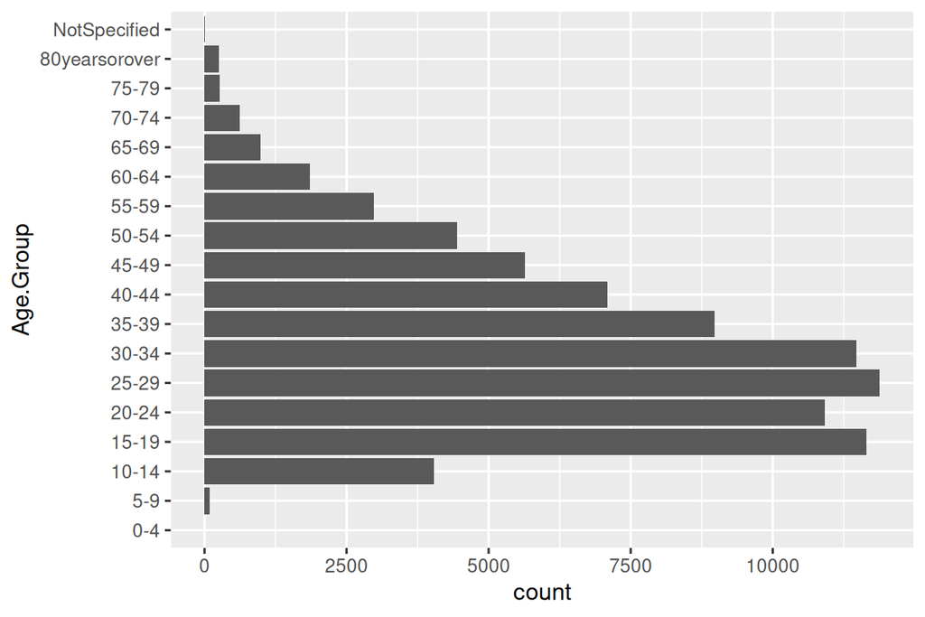

# Stats

- `geom_histogram()` uses `stat_bin()`.

  This bins raw quantitative data and maps the resulting bin boundaries and counts to the position and length of bars.
- `geom_density()` uses `stat_density()`.

  This calculates a density estimate from raw quantitative data and maps the resulting density to the position of a line.
- `geom_smooth()` uses `stat_smooth()`.

  This takes raw quantitative x and y data, calculates smoothed y values, and maps those to the position of a line.

# Rugby World Cup

- The `RWCperGame` data frame contains measures of performance at the Rugby World Cup of 2023 for different countries, plus the `hemisphere` that each country is from.

  ```r
  head(tibble(RWCperGame))
  ```

  ```
  # A tibble: 6 × 11
    country   hemisphere yellowcards redcards cleanbreaks
    <chr>     <fct>            <dbl>    <dbl>       <dbl>
  1 Namibia   South             1        0.5         2.5
  2 Romania   North             1.25     0           2.75
  3 Chile     South             1.25     0           3.75
  4 Samoa     South             1.25     0.25        3.75
  5 Australia South             0.5      0           5.25
  6 Georgia   North             0.5      0           5.25
  # ℹ 6 more variables: tackles <dbl>, points <dbl>,
  #   conversions <dbl>, offloads <dbl>, tries <dbl>,
  #   runs <dbl>
  ```

# Stats

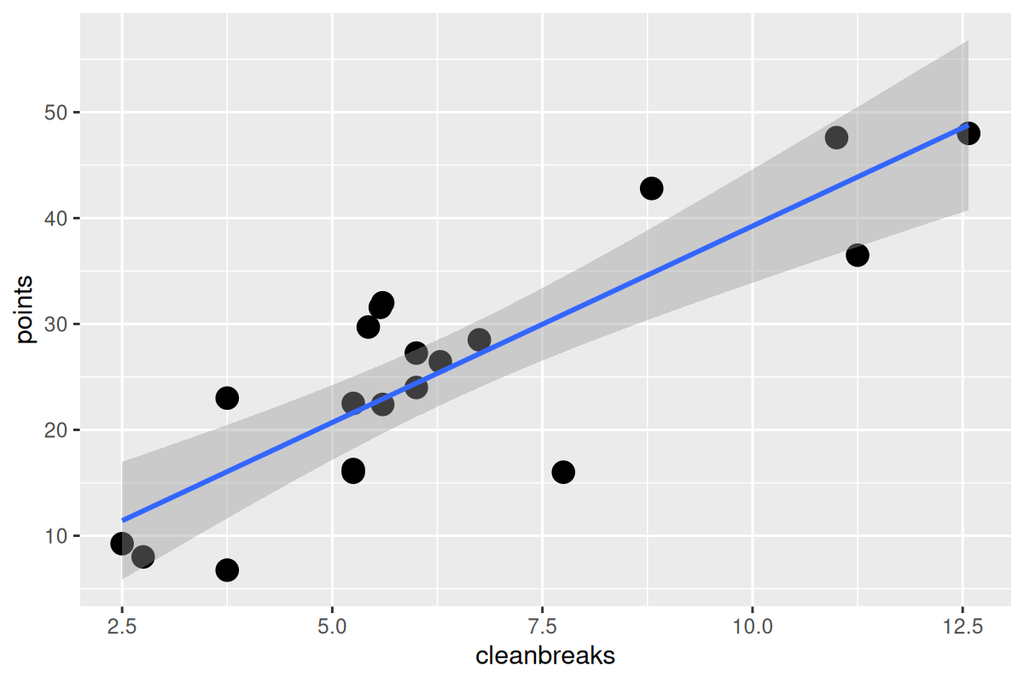

```r
ggplot(RWCperGame, aes(x = cleanbreaks, y = points)) +
    geom_point() +
    geom_smooth(method="lm")
```

# Stats

- Note that if we produce a data symbol from data statistics, we can only map back to the data statistics.

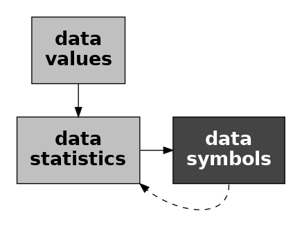

# {ggplot2} Help

- The [help pages for individual geoms](https://ggplot2.tidyverse.org/reference/geom_bar.html) describe:
  - the **aesthetics** for a geom.
  - the **stat** for a geom.

Summary

# Summary

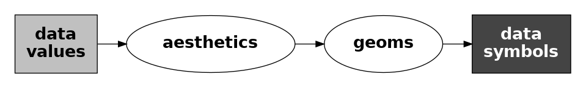

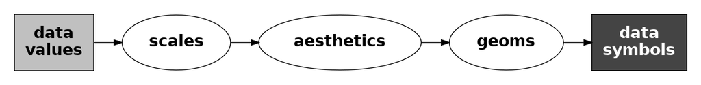

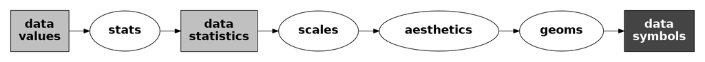

Exercises

# Exercise

- We will produce several data visualisations using the `rates` data frame.

  ```r
  head(rates)
  ```

  ```
    Age Year Rate
  1  10 2010   66
  2  11 2010  120
  3  12 2010  211
  4  13 2010  392
  6  10 2011   62
  7  11 2011  107
  ```